# F9_05_170C_FUNDS_FOR_PREMIUM_X

Received funds to pay premiums on a personal benefit contract [x] · Checkbox report

## Overview

**Description**

Funds to pay premiums?

**Table**

`F9-P05-T00-OTHER-IRS-FILING` (one)

**Location code**

`F990-PC-PART-05-LINE-07E`, `F990-PC-PART-05-LINE-7E`

**Family**

`F990-PC-PART-05-LINE-07E`

**Data type**

checkbox (xsd: , BooleanType)

**Scope**

PC, PZ

**Status**

unreviewed

5

xpaths mapped (4 observed)

2,625,739

filings with a value

2009–2024

tax years observed

4

open flags (2 errors)

## Flags

| Severity | Flag | Xpath | Detail |
| --- | --- | --- | --- |
| ⚠ error | `TYPE_CHECKBOX` | TransferPrsnlBnftContractsDecl/DeclarationDesc | checkbox variable; 0% of values are X/true/false/1/0 |
| ⚠ error | `TYPE_CHECKBOX` | TransferPrsnlBnftContractsDecl/Declaration | checkbox variable; 0% of values are X/true/false/1/0 |
| ▲ warn | `NAME_SUFFIX` | TransferPrsnlBnftContractsDecl/DeclarationDesc | element suffix implies text; variable is checkbox |
| ⓘ info | `UNOBSERVED` | IRS990/Form990PartV/FundsToPayPremiums | never observed in TY2009-2024 filings |

## Xpaths

All mapped xpaths (under /Return/ReturnData or /Return/ReturnHeader), oldest first. Charts label each series by its xpath.

| Xpath | Form | First year | Last year | Versions | Filings | Repeats in |
| --- | --- | --- | --- | --- | --- | --- |
| IRS990/FundsToPayPremiums | 990 | 2009 | 2012 | 18 | 311,917 | 0.0% |
| TransferPrsnlBnftContractsDecl/Declaration | TransferPrsnlBnftContractsDecl | 2009 | 2012 | 11 | 55,535 | 0.0% |
| IRS990/RcvFndsToPayPrsnlBnftCntrctInd | 990 | 2013 | 2024 | 38 | 1,948,267 | 0.0% |
| TransferPrsnlBnftContractsDecl/DeclarationDesc | TransferPrsnlBnftContractsDecl | 2013 | 2024 | 32 | 310,020 | 0.0% |
| IRS990/Form990PartV/FundsToPayPremiums | 990 |  |  |  | 0 |  |

## Coverage

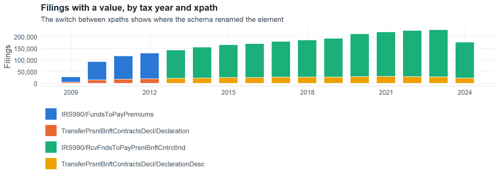

**Table view**

Table view: filings by tax year and series

| Tax year | IRS990/FundsToPayPremiums | TransferPrsnlBnftContractsDecl/Declaration | IRS990/RcvFndsToPayPrsnlBnftCntrctInd | TransferPrsnlBnftContractsDecl/DeclarationDesc |
| --- | --- | --- | --- | --- |
| 2009 | 23,311 | 4,645 | 0 | 0 |
| 2010 | 78,676 | 13,949 | 0 | 0 |
| 2011 | 99,308 | 17,639 | 0 | 0 |
| 2012 | 110,622 | 19,302 | 0 | 0 |
| 2013 | 0 | 0 | 121,583 | 21,079 |
| 2014 | 0 | 0 | 132,550 | 22,907 |
| 2015 | 0 | 0 | 140,869 | 24,234 |
| 2016 | 0 | 0 | 145,465 | 25,018 |
| 2017 | 0 | 0 | 153,168 | 26,174 |
| 2018 | 0 | 0 | 159,328 | 26,713 |
| 2019 | 0 | 0 | 165,737 | 27,033 |
| 2020 | 0 | 0 | 183,790 | 28,471 |
| 2021 | 0 | 0 | 191,695 | 29,325 |
| 2022 | 0 | 0 | 198,418 | 28,587 |
| 2023 | 0 | 0 | 201,776 | 28,010 |
| 2024 | 0 | 0 | 153,888 | 22,469 |

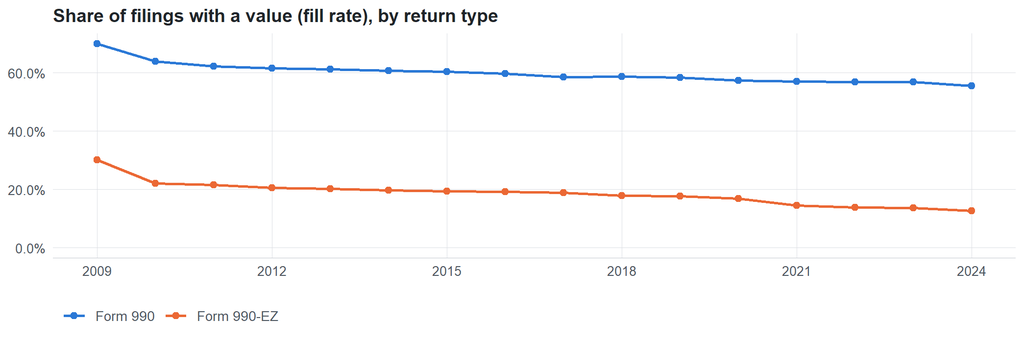

**Table view**

Table view: fill rate

| Tax year | Return type | Filings | All filings | Fill rate |
| --- | --- | --- | --- | --- |
| 2009 | Form 990 | 23,311 | 33,311 | 69.98% |
| 2009 | Form 990-EZ | 4,645 | 15,470 | 30.03% |
| 2010 | Form 990 | 78,676 | 123,025 | 63.95% |
| 2010 | Form 990-EZ | 13,949 | 63,326 | 22.03% |
| 2011 | Form 990 | 99,308 | 159,504 | 62.26% |
| 2011 | Form 990-EZ | 17,639 | 82,048 | 21.50% |
| 2012 | Form 990 | 110,622 | 179,688 | 61.56% |
| 2012 | Form 990-EZ | 19,302 | 93,750 | 20.59% |
| 2013 | Form 990 | 121,583 | 198,855 | 61.14% |
| 2013 | Form 990-EZ | 21,079 | 104,375 | 20.20% |
| 2014 | Form 990 | 132,550 | 218,619 | 60.63% |
| 2014 | Form 990-EZ | 22,907 | 116,417 | 19.68% |
| 2015 | Form 990 | 140,869 | 233,519 | 60.32% |
| 2015 | Form 990-EZ | 24,234 | 124,894 | 19.40% |
| 2016 | Form 990 | 145,465 | 243,903 | 59.64% |
| 2016 | Form 990-EZ | 25,018 | 130,484 | 19.17% |
| 2017 | Form 990 | 153,168 | 261,612 | 58.55% |
| 2017 | Form 990-EZ | 26,174 | 139,144 | 18.81% |
| 2018 | Form 990 | 159,328 | 271,442 | 58.70% |
| 2018 | Form 990-EZ | 26,713 | 149,384 | 17.88% |
| 2019 | Form 990 | 165,737 | 283,694 | 58.42% |
| 2019 | Form 990-EZ | 27,033 | 152,622 | 17.71% |
| 2020 | Form 990 | 183,789 | 320,342 | 57.37% |
| 2020 | Form 990-EZ | 28,471 | 169,864 | 16.76% |
| 2021 | Form 990 | 191,691 | 336,480 | 56.97% |
| 2021 | Form 990-EZ | 29,325 | 202,724 | 14.47% |
| 2022 | Form 990 | 198,416 | 349,055 | 56.84% |
| 2022 | Form 990-EZ | 28,587 | 206,130 | 13.87% |
| 2023 | Form 990 | 201,774 | 354,768 | 56.87% |
| 2023 | Form 990-EZ | 28,010 | 206,379 | 13.57% |
| 2024 | Form 990 | 153,887 | 277,298 | 55.50% |
| 2024 | Form 990-EZ | 22,469 | 178,867 | 12.56% |

## Values

| Result | Check | Detail |
| --- | --- | --- |
| ⚠ fail | Values are checkbox codes | 86.1% of values are X / true / false / 1 / 0 |
| ⓘ info | Meaning of a blank | 86% of values are explicit false/0, so a missing value is not the same as unchecked |
| ✓ pass | Element names agree in polarity | all element names have the same polarity |

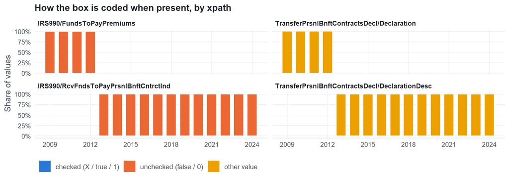

**Table view**

Table view: value coding by tax year

| Series | Tax year | Code | Filings | Share |
| --- | --- | --- | --- | --- |
| IRS990/FundsToPayPremiums | 2009 | checked (X / true / 1) | 53 | 0.2% |
| IRS990/FundsToPayPremiums | 2009 | unchecked (false / 0) | 23,258 | 99.8% |
| IRS990/FundsToPayPremiums | 2010 | checked (X / true / 1) | 107 | 0.1% |
| IRS990/FundsToPayPremiums | 2010 | unchecked (false / 0) | 78,569 | 99.9% |
| IRS990/FundsToPayPremiums | 2011 | checked (X / true / 1) | 94 | 0.1% |
| IRS990/FundsToPayPremiums | 2011 | unchecked (false / 0) | 99,214 | 99.9% |
| IRS990/FundsToPayPremiums | 2012 | checked (X / true / 1) | 85 | 0.1% |
| IRS990/FundsToPayPremiums | 2012 | unchecked (false / 0) | 110,537 | 99.9% |
| TransferPrsnlBnftContractsDecl/Declaration | 2009 | other value | 4,645 | 100.0% |
| TransferPrsnlBnftContractsDecl/Declaration | 2010 | other value | 13,949 | 100.0% |
| TransferPrsnlBnftContractsDecl/Declaration | 2011 | other value | 17,639 | 100.0% |
| TransferPrsnlBnftContractsDecl/Declaration | 2012 | other value | 19,302 | 100.0% |
| IRS990/RcvFndsToPayPrsnlBnftCntrctInd | 2013 | checked (X / true / 1) | 92 | 0.1% |
| IRS990/RcvFndsToPayPrsnlBnftCntrctInd | 2013 | unchecked (false / 0) | 121,491 | 99.9% |
| IRS990/RcvFndsToPayPrsnlBnftCntrctInd | 2014 | checked (X / true / 1) | 90 | 0.1% |
| IRS990/RcvFndsToPayPrsnlBnftCntrctInd | 2014 | unchecked (false / 0) | 132,460 | 99.9% |
| IRS990/RcvFndsToPayPrsnlBnftCntrctInd | 2015 | checked (X / true / 1) | 119 | 0.1% |
| IRS990/RcvFndsToPayPrsnlBnftCntrctInd | 2015 | unchecked (false / 0) | 140,750 | 99.9% |
| IRS990/RcvFndsToPayPrsnlBnftCntrctInd | 2016 | checked (X / true / 1) | 90 | 0.1% |
| IRS990/RcvFndsToPayPrsnlBnftCntrctInd | 2016 | unchecked (false / 0) | 145,375 | 99.9% |
| IRS990/RcvFndsToPayPrsnlBnftCntrctInd | 2017 | checked (X / true / 1) | 104 | 0.1% |
| IRS990/RcvFndsToPayPrsnlBnftCntrctInd | 2017 | unchecked (false / 0) | 153,064 | 99.9% |
| IRS990/RcvFndsToPayPrsnlBnftCntrctInd | 2018 | checked (X / true / 1) | 118 | 0.1% |
| IRS990/RcvFndsToPayPrsnlBnftCntrctInd | 2018 | unchecked (false / 0) | 159,210 | 99.9% |
| IRS990/RcvFndsToPayPrsnlBnftCntrctInd | 2019 | checked (X / true / 1) | 125 | 0.1% |
| IRS990/RcvFndsToPayPrsnlBnftCntrctInd | 2019 | unchecked (false / 0) | 165,612 | 99.9% |
| IRS990/RcvFndsToPayPrsnlBnftCntrctInd | 2020 | checked (X / true / 1) | 147 | 0.1% |
| IRS990/RcvFndsToPayPrsnlBnftCntrctInd | 2020 | unchecked (false / 0) | 183,643 | 99.9% |
| IRS990/RcvFndsToPayPrsnlBnftCntrctInd | 2021 | checked (X / true / 1) | 109 | 0.1% |
| IRS990/RcvFndsToPayPrsnlBnftCntrctInd | 2021 | unchecked (false / 0) | 191,586 | 99.9% |
| IRS990/RcvFndsToPayPrsnlBnftCntrctInd | 2022 | checked (X / true / 1) | 93 | 0.0% |
| IRS990/RcvFndsToPayPrsnlBnftCntrctInd | 2022 | unchecked (false / 0) | 198,325 | 100.0% |
| IRS990/RcvFndsToPayPrsnlBnftCntrctInd | 2023 | checked (X / true / 1) | 92 | 0.0% |
| IRS990/RcvFndsToPayPrsnlBnftCntrctInd | 2023 | unchecked (false / 0) | 201,684 | 100.0% |
| IRS990/RcvFndsToPayPrsnlBnftCntrctInd | 2024 | checked (X / true / 1) | 57 | 0.0% |
| IRS990/RcvFndsToPayPrsnlBnftCntrctInd | 2024 | unchecked (false / 0) | 153,831 | 100.0% |
| TransferPrsnlBnftContractsDecl/DeclarationDesc | 2013 | other value | 21,079 | 100.0% |
| TransferPrsnlBnftContractsDecl/DeclarationDesc | 2014 | other value | 22,853 | 100.0% |
| TransferPrsnlBnftContractsDecl/DeclarationDesc | 2015 | other value | 24,146 | 100.0% |
| TransferPrsnlBnftContractsDecl/DeclarationDesc | 2016 | other value | 24,902 | 100.0% |
| TransferPrsnlBnftContractsDecl/DeclarationDesc | 2017 | other value | 26,030 | 100.0% |
| TransferPrsnlBnftContractsDecl/DeclarationDesc | 2018 | other value | 26,567 | 100.0% |
| TransferPrsnlBnftContractsDecl/DeclarationDesc | 2019 | other value | 26,864 | 100.0% |
| TransferPrsnlBnftContractsDecl/DeclarationDesc | 2020 | other value | 28,270 | 100.0% |
| TransferPrsnlBnftContractsDecl/DeclarationDesc | 2021 | other value | 29,118 | 100.0% |
| TransferPrsnlBnftContractsDecl/DeclarationDesc | 2022 | other value | 28,360 | 100.0% |
| TransferPrsnlBnftContractsDecl/DeclarationDesc | 2023 | other value | 27,807 | 100.0% |
| TransferPrsnlBnftContractsDecl/DeclarationDesc | 2024 | other value | 22,392 | 100.0% |

Raw values by xpath (all years)

Series

Value

Filings

IRS990/FundsToPayPremiums

false

181,784

IRS990/FundsToPayPremiums

0

129,794

IRS990/FundsToPayPremiums

1

213

IRS990/FundsToPayPremiums

true

126

TransferPrsnlBnftContractsDecl/Declaration

THE ORGANIZATION DID NOT, DURING THE YEAR, RECEIVE ANY FUNDS, DIRECTLY,OR INDIRECTLY, TO PAY PREMIUM

44,856

TransferPrsnlBnftContractsDecl/Declaration

The organization did not, during the year, receive any funds, directly,or indirectly, to pay premium

10,661

TransferPrsnlBnftContractsDecl/Declaration

THE ORGANIZATION RECEIVED, DURING THE YEAR, FUNDS, DIRECTLY OR INDIRECTLY,TO PAY PREMIUMS ON A PERSO

12

TransferPrsnlBnftContractsDecl/Declaration

NONE

2

TransferPrsnlBnftContractsDecl/Declaration

None

1

TransferPrsnlBnftContractsDecl/Declaration

The Organization did not, at any time during the year, receive funds directly or indirectly to pay p

1

TransferPrsnlBnftContractsDecl/Declaration

The organization did not, during the year, receive any funds directly, or indirectly, to pay premium

1

TransferPrsnlBnftContractsDecl/Declaration

THE ORGANIZATION DID NOT, DURING THE YEAR, RECEIVE ANY FUNDS, DIRECTLY, OR INDIRECTLY, TO PAY PREMIU

1

IRS990/RcvFndsToPayPrsnlBnftCntrctInd

false

1,255,590

IRS990/RcvFndsToPayPrsnlBnftCntrctInd

0

691,441

IRS990/RcvFndsToPayPrsnlBnftCntrctInd

1

748

IRS990/RcvFndsToPayPrsnlBnftCntrctInd

true

488

TransferPrsnlBnftContractsDecl/DeclarationDesc

THE ORGANIZATION DID NOT, DURING THE YEAR, RECEIVE ANY FUNDS, DIRECTLY,OR INDIRECTLY, TO PAY PREMIUM

262,224

TransferPrsnlBnftContractsDecl/DeclarationDesc

The organization did not, during the year, receive any funds, directly,or indirectly, to pay premium

40,914

TransferPrsnlBnftContractsDecl/DeclarationDesc

THE ORGANIZATION DID NOT, DURING THE YEAR, RECEIVE ANY FUNDS, DIRECTLY, OR INDIRECTLY, TO PAY PREMIU

2,807

TransferPrsnlBnftContractsDecl/DeclarationDesc

THE ORGANIZATION DID NOT, DURING THE YEAR, RECEIVE ANY FUNDS, DIRECTLY OR INDIRECTLY, TO PAY PREMIUM

1,294

TransferPrsnlBnftContractsDecl/DeclarationDesc

1. DID THE ORGANIZATION, DURING THE YEAR, RECEIVE ANY FUNDS, DIRECTLY OR INDIRECTLY, TO PAY PREMIUM

372

TransferPrsnlBnftContractsDecl/DeclarationDesc

DID THE ORGANIZATION RECEIVE ANY FUNDS, DIRECTLY OR INDIRECTLY, TO PAY PREMIUMS ON A PERSONAL BENEFI

349

TransferPrsnlBnftContractsDecl/DeclarationDesc

DURING THE YEAR, THE ORGANIZATION DID NOT RECEIVE ANY FUNDS, DIRECTLY OR INDIRECTLY, TO PAY PREMIUMS

111

TransferPrsnlBnftContractsDecl/DeclarationDesc

THE ORGANIZATION DID NOT, DURING THE YEAR, RECEIVE ANY FUNDS DIRECTLY OR INDIRECTLY TO PAY PREMIUMS

91

TransferPrsnlBnftContractsDecl/DeclarationDesc

THE ORGANIZATION DID NOT DURING THE YEAR RECEIVE ANY FUNDS, DIRECTLY OR INDIRECTLY, TO PAY PREMIUMS

78

TransferPrsnlBnftContractsDecl/DeclarationDesc

INFORMATION REGARDING PERSONAL BENEFIT CONTRACTS: THE ORGANIZATION DID NOT, DURING THE YEAR, RECEIVE

54

TransferPrsnlBnftContractsDecl/DeclarationDesc

NONE

32

TransferPrsnlBnftContractsDecl/DeclarationDesc

THE ORGANIZATION DID NOT DURING THE YEAR RECEIVE ANY FUNDS DIRECTLY OR INDIRECTLY TO PAY PREMIUMS ON

29

TransferPrsnlBnftContractsDecl/DeclarationDesc

THE ORGANIZATION DID NOT, DURING THE YEAR, RECEIVE ANY FUNDS DIRECTLY OR INDIRECTLY, TO PAY PREMIUMS

7

TransferPrsnlBnftContractsDecl/DeclarationDesc

THE ORGANIZATION RECEIVED, DURING THE YEAR, FUNDS, DIRECTLY OR INDIRECTLY,TO PAY PREMIUMS ON A PERSO

6

TransferPrsnlBnftContractsDecl/DeclarationDesc

FORM 990-EZ, PART V, INFORMATION REGARDING PERSONAL BENEFIT CONTRACTS: THE ORGANIZATION DID NOT, DUR

6

TransferPrsnlBnftContractsDecl/DeclarationDesc

THE ORGANIZATION DID NOT RECEIVE ANY FUNDS, DIRECTLY OR INDIRECTLY, TO PAY PREMIUMS ON A PERSONAL BE

6

TransferPrsnlBnftContractsDecl/DeclarationDesc

THE ORGANIZATION DID NOT RECEIVE ANY FUNDS DIRECTLY OR INDIRECTLY TO PAY PREMIUMS ON A PERSONAL BENE

4

TransferPrsnlBnftContractsDecl/DeclarationDesc

THE ORGANIZATION DID NOT DIRECTLY OR INDIRECTLY PAY PREMIUMS ON A PERSONAL BENEFIT CONTRACT.

3

TransferPrsnlBnftContractsDecl/DeclarationDesc

THE ORGANIZATION DID NOT, DURIGN THE YEAR, RECEIVE ANY FUNDS, DIRECTLY, OR INDIRECTLY, TO PAY PREMUI

1

## Examples

| Tax year | Return | Xpath | Organization | Value | Source |
| --- | --- | --- | --- | --- | --- |
| 2024 | 990 | IRS990/RcvFndsToPayPrsnlBnftCntrctInd | RISEWELL COMMUNITY SERVICES INC FKA | 0 | [XML](https://gt990datalake-rawdata.s3.amazonaws.com/EfileData/XmlFiles/202610589349301811_public.xml) |
| 2024 | 990EZ | TransferPrsnlBnftContractsDecl/DeclarationDesc | KYLE GOLDBERG MEMORIAL FOUNDATION | THE ORGANIZATION DID NOT, DURING THE YEAR, RECEIVE ANY FUNDS, DIRECTLY,OR INDIRECTLY, TO PAY PREMIUM | [XML](https://gt990datalake-rawdata.s3.amazonaws.com/EfileData/XmlFiles/202511219349201801_public.xml) |
| 2023 | 990 | IRS990/RcvFndsToPayPrsnlBnftCntrctInd | SCENIC RIVERS LAND TRUST INC | false | [XML](https://gt990datalake-rawdata.s3.amazonaws.com/EfileData/XmlFiles/202403109349303230_public.xml) |
| 2023 | 990EZ | TransferPrsnlBnftContractsDecl/DeclarationDesc | THE LIFE PLANNING NETWORK INC | THE ORGANIZATION DID NOT, DURING THE YEAR, RECEIVE ANY FUNDS, DIRECTLY,OR INDIRECTLY, TO PAY PREMIUM | [XML](https://gt990datalake-rawdata.s3.amazonaws.com/EfileData/XmlFiles/202432259349200968_public.xml) |
| 2022 | 990 | IRS990/RcvFndsToPayPrsnlBnftCntrctInd | XERODERMA PIGMENTOSUM FAMILY | false | [XML](https://gt990datalake-rawdata.s3.amazonaws.com/EfileData/XmlFiles/202303129349302100_public.xml) |
| 2022 | 990EZ | TransferPrsnlBnftContractsDecl/DeclarationDesc | MARYLAND BIODIVERSITY PROJECT INC | THE ORGANIZATION DID NOT, DURING THE YEAR, RECEIVE ANY FUNDS, DIRECTLY,OR INDIRECTLY, TO PAY PREMIUM | [XML](https://gt990datalake-rawdata.s3.amazonaws.com/EfileData/XmlFiles/202320449349200932_public.xml) |
| 2021 | 990 | IRS990/RcvFndsToPayPrsnlBnftCntrctInd | COULEE REGION HUMANE SOCIETY INC | false | [XML](https://gt990datalake-rawdata.s3.amazonaws.com/EfileData/XmlFiles/202243119349301379_public.xml) |
| 2021 | 990EZ | TransferPrsnlBnftContractsDecl/DeclarationDesc | EK KARDIA INC | THE ORGANIZATION DID NOT, DURING THE YEAR, RECEIVE ANY FUNDS, DIRECTLY,OR INDIRECTLY, TO PAY PREMIUM | [XML](https://gt990datalake-rawdata.s3.amazonaws.com/EfileData/XmlFiles/202302139349201510_public.xml) |
| 2020 | 990 | IRS990/RcvFndsToPayPrsnlBnftCntrctInd | Ministerios Torre Fuerte Internacional | false | [XML](https://gt990datalake-rawdata.s3.amazonaws.com/EfileData/XmlFiles/202101689349301500_public.xml) |
| 2020 | 990EZ | TransferPrsnlBnftContractsDecl/DeclarationDesc | PEACE OF MIND INC | THE ORGANIZATION DID NOT, DURING THE YEAR, RECEIVE ANY FUNDS, DIRECTLY,OR INDIRECTLY, TO PAY PREMIUM | [XML](https://gt990datalake-rawdata.s3.amazonaws.com/EfileData/XmlFiles/202121419349200607_public.xml) |
| 2019 | 990 | IRS990/RcvFndsToPayPrsnlBnftCntrctInd | FOSTERING HOPE | 0 | [XML](https://gt990datalake-rawdata.s3.amazonaws.com/EfileData/XmlFiles/202033519349300713_public.xml) |
| 2019 | 990EZ | TransferPrsnlBnftContractsDecl/DeclarationDesc | FRANCISCAN MONASTERY GARDEN GUILD | THE ORGANIZATION DID NOT, DURING THE YEAR, RECEIVE ANY FUNDS, DIRECTLY,OR INDIRECTLY, TO PAY PREMIUM | [XML](https://gt990datalake-rawdata.s3.amazonaws.com/EfileData/XmlFiles/202031909349200733_public.xml) |

## Reviewer checklist

- The definition matches the form line and instructions for every xpath’s schema years.
- Every xpath pooled here measures the same thing on the 990 and 990-EZ (close enough for analysis).
- The coverage chart has no unexplained gaps or jumps between tax years.
- Each open flag is fixed, or accepted with a note in validation_log.csv.
- The box means the same thing (and the same polarity) under every xpath: ‘required’ is never pooled with ‘not required’.
- Absent means unchecked for this line, or the question was skipped; the data dictionary says which.
- Yes/No questions coded as two separate boxes are mapped to one variable only when that is intended.

Record the review as a row in `inst/extdata/src/validation_log.csv` (variable_name, reviewer, date, status, note). Evidence built 2026-09-23 17:09:04 MST from the ef2 DuckDB builds (tax years 2009–2024).